# Somateria mollissima escape distance

V. Khaitov

2026-01-10

Зависимая переменная сильно асимметрично распределена.

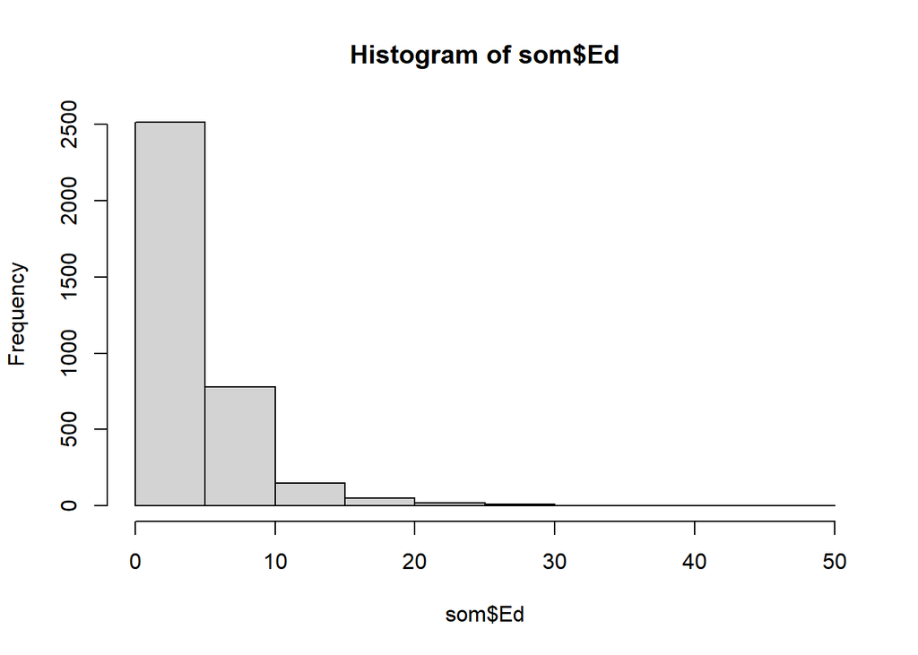

Поэтому, увы, будем ее логарифмировать (позднее подумаю, может какое иное преобразование применем). Распределение логарифмированной переменной более человекообразное.

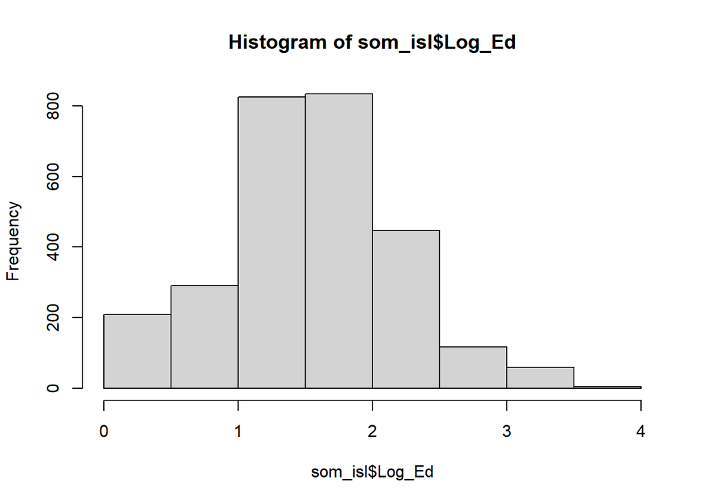

Модель, которую я построил на данном этапе имеет следующий вид

```r
mod <- gam(Log_Ed ~
             s(incubation_period) +
             s(N_eggs, k = 4) +
             s(Year, k = 6) +
             s(Log_Area, k = 5 ) +
             s(Dist_to_Mainland) +
             s(Dist_to_town, k = 5)  +
             Region +
             s(Place, k = 87, bs = "re"),
           data = som_isl)
```

Проверяем валидность модели

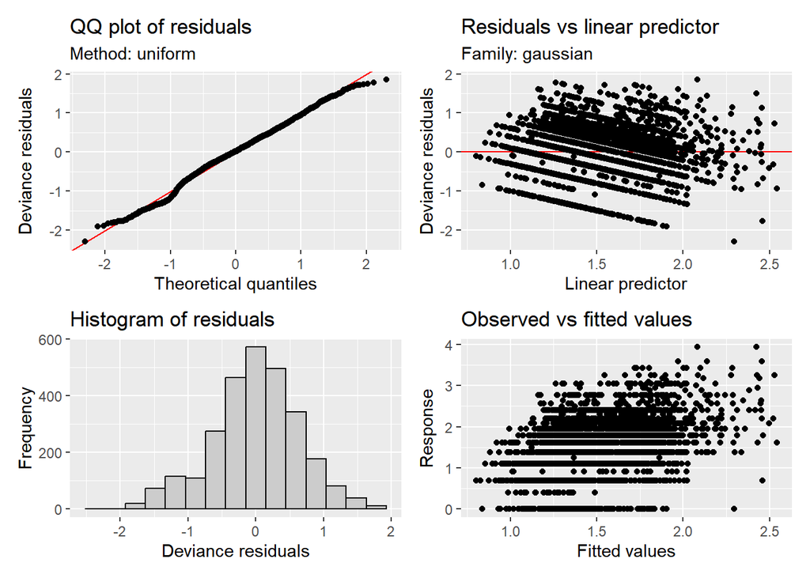

Не супер, но и не ужас-ужас-ужас…

Вот summary от этой модели

```
##
## Family: gaussian
## Link function: identity
##
## Formula:
## Log_Ed ~ s(incubation_period) + s(N_eggs, k = 4) + s(Year, k = 6) +
##     s(Log_Area, k = 5) + s(Dist_to_Mainland) + s(Dist_to_town,
##     k = 5) + Region + s(Place, k = 87, bs = "re")
##
## Parametric coefficients:
##                         Estimate Std. Error t value Pr(>|t|)
## (Intercept)               1.3730     0.1406   9.768  < 2e-16 ***
## RegionOleny arhipelag     0.4202     0.1215   3.459  0.00055 ***
## RegionSeverny arhipelag   0.1079     0.1941   0.556  0.57834
## ---
## Signif. codes:  0 '***' 0.001 '**' 0.01 '*' 0.05 '.' 0.1 ' ' 1
##
## Approximate significance of smooth terms:
##                         edf Ref.df      F  p-value
## s(incubation_period)  4.152  5.092 35.928  < 2e-16 ***
## s(N_eggs)             1.729  2.095  4.155   0.0137 *
## s(Year)               2.371  2.925  9.049 1.11e-05 ***
## s(Log_Area)           1.000  1.000  6.378   0.0116 *
## s(Dist_to_Mainland)   1.449  1.578  0.430   0.4574
## s(Dist_to_town)       1.990  2.188  1.870   0.1002
## s(Place)             34.807 81.000  1.008  < 2e-16 ***
## ---
## Signif. codes:  0 '***' 0.001 '**' 0.01 '*' 0.05 '.' 0.1 ' ' 1
##
## R-sq.(adj) =  0.167   Deviance explained = 18.2%
## GCV = 0.42464  Scale est. = 0.41693   n = 2784
```

Итого, значимые связи выявляются с фактором “Region”, и со следующими непрерывными ковариатами: incubation_period, N_eggs, Year, Log_Area (взяты логарифмы площадей островов, так как там есть несколько больших островов оутлаеров).

Визуализации связей следующие (привожу только занчимые связи).

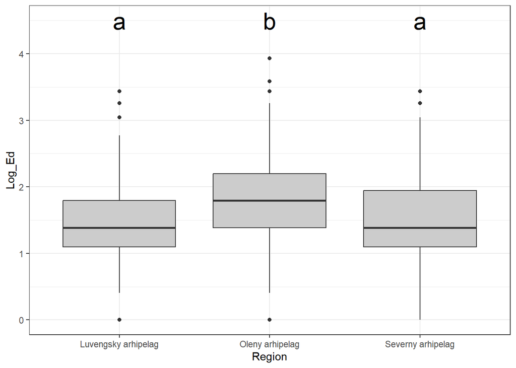

Вот результаты попарного сравнения Log_Ed в разных архипелагах

```
##
## Wald test
## -----
## mod: Log_Ed ~ s(incubation_period) + s(N_eggs, k = 4) + s(Year, k = 6) +
##     s(Log_Area, k = 5) + s(Dist_to_Mainland) + s(Dist_to_town,
##     k = 5) + Region + s(Place, k = 87, bs = "re")
##
## Parametric effects:
##             (Intercept)   RegionOleny arhipelag RegionSeverny arhipelag
##               1.3729684               0.4201941               0.1079158
##
## Null hypothesis =  0
##
## Comparing Oleny arhipelag with Severny arhipelag:
##  X2(1.000) = 6.599, p = 0.010 *
##
##  Comparing Luvengsky arhipelag with Severny arhipelag:
##  X2(1.000) = 0.309, p = 0.578
##
##  Comparing Luvengsky arhipelag with Oleny arhipelag:
##  X2(1.000) = 11.966, p = 5.42e-04 ***
```

Ну… да, на островах Оленьего архипелага гаги взлетают раньше, чем на островах более заповедных.

А вот с остальными предикторами все смешнее.

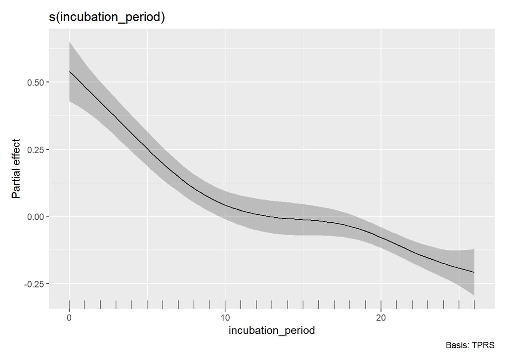

Здесь все понятно. Чем больше период насиживания, тем ближе подпускает гага к себе человека.

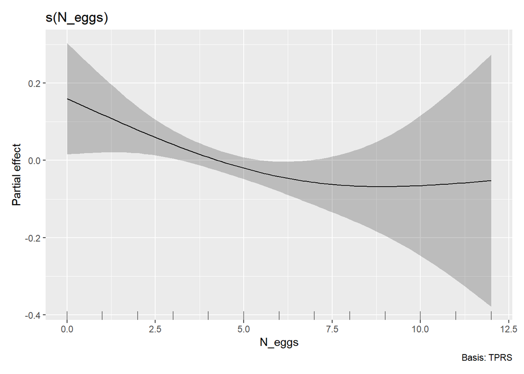

Эта связь, скорее всего означает, что пока кладка не завершена гага осторожничает.

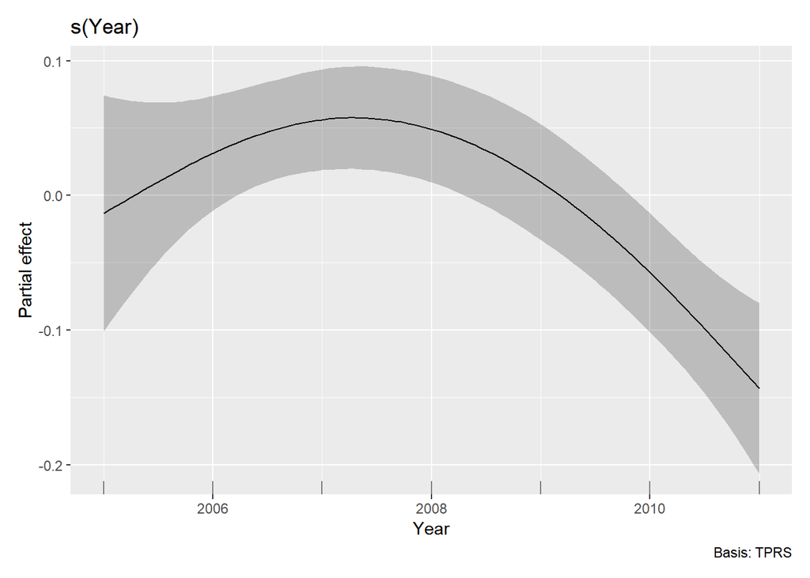

А вот этот график очень показательный. Кто научился за перод наблюдений? Гаги научились подпускать ближе или люди научились подкрадываться тише?

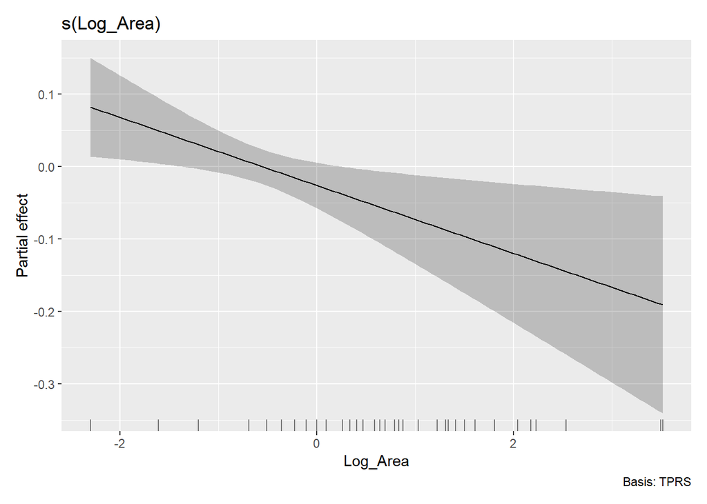

Эту связь очень легко объяснить, тем, что на малых островах незамеченным не подойдешь и гаги более остоожные, чем н аболее крупных островах. Впрочем, может тут и хищники виноваты. Пока не выяснил как тут играет роль плотность поселения. Позднее вставлю в модель.

Остальные пока изученные ковариаты не влияют.